# Homework 1

Cristina, Laura, Emil, Louis, Federico

08 October, 2018

## Introduction

```r
summary(cars)
```

```
##      speed           dist
##  Min.   : 4.0   Min.   :  2.00
##  1st Qu.:12.0   1st Qu.: 26.00
##  Median :15.0   Median : 36.00
##  Mean   :15.4   Mean   : 42.98
##  3rd Qu.:19.0   3rd Qu.: 56.00
##  Max.   :25.0   Max.   :120.00
```

## Group Members

### Cristina

My name is Cristina and I come from Milan, Italy where I am studying Business Analytics and Big Data at Politecnico di Milano. Right now I am at HEC in Lausanne as an exchange student within the QTEM master’s network. During this months I will attend the following courses:

| Class | Time |
| --- | --- |
| Programming Tools in Data Science | Tueseday 1:15 pm |
| Computational Tools for Actuaries | Thuesday 8:30 am |
| Conceptual Modelling for Business Analytics | Thuesday 1:30 pm |
| Data Analytics for Decision Making | Friday 8:30 am |

The things that I am passionate about are:

- Sports: Volleyball, Skii, Surf, Wakeboard
- Art: I love reading about art and going to exibitions, expecially about Contemporary Art
- Music: I listen to Rock, Indie-rock and Electronic music and I love going to concerts and festivals
- Travel: I like discover new cultures and meet new people

A **fun fact** about me is that I am super clumsy, I have the ability to drop everything I am holding and to hit everything that is around me. So don’t ask me to hold your phone or to take care of something precious if you don’t want it totally smashed :D

#### Cristina’s Favourite Quote

> “Whenever humanity seems condemned to heaviness, I think I should fly like Perseus into a different space. I don’t mean escaping into dreams or the irrational. I mean that I have to change my approach, look at the world from a different perspective, with a different logic and with fresh methods of cognition and verification.”

> Italo Calvino, Six Memos For The Next Millennium

### Louis

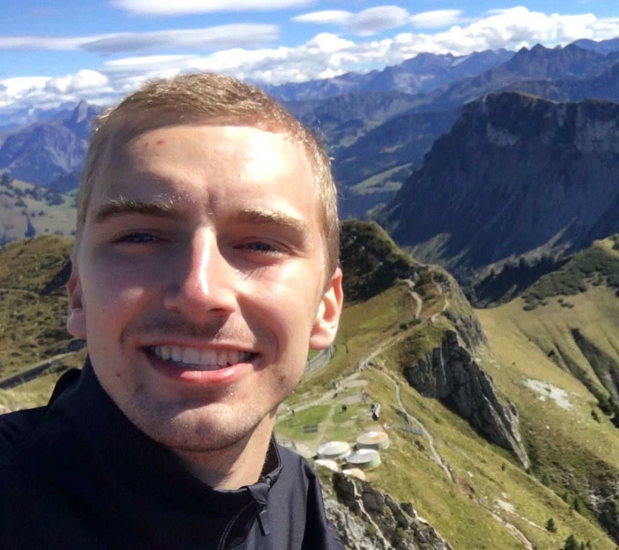

Enjoying the Swiss mountains

I’ll say yes to anything you offer me to do but I am particularly fond of

- Theatre
- Running
- Classical music
  - Brams
  - Litz
  - Beethoven
- Tennis

I am also very good at learning new languages and therefore enjoy to learn new ones.

A **fun fact** about me is that my grandpa has written an encyclopedia of 18 volumes about the European litterature.

> “Ce que les gens ne peuvent pas comprendre leur fait peur, et ce qui leur fait peur ils veulent le détruire”

> Werber, L’Ultime Secret

| Class | Time |
| --- | --- |
| Data Mining | Monday 8:30 am |
| Programming Tools in Data Science | Tueseday 1:15 pm |
| Machine Learning in Business Analytics | Wednesday 1:15 pm |
| Optimization Methods in Business Analytics | Friday 3:15 pm |

## RMarkdown Syntax

```r
a <- Sys.time()
print(paste0("Today is the ", a))
```

```
## [1] "Today is the 2018-10-08 17:42:11"
```

> “Vérité dans un temps, erreur dans un autre.”

## References

Cristina’s Favourite Quote is taken from: Calvino (2016)

Calvino, Italo. 2016. *Six Memos for the Next Millennium*. Houghton Mifflin Harcourt.